# Data Visualisation with R

September 2020

## Data Visualisation

Data visualisation is imperative to data analysis. Representing data through a visual medium is an effective means of communicating key insights of the analysis.

In R, we primarily use **ggplot2**, one of the most versatile and effective packages for data visualisation. To install and load this package, we can use the following code:

```r
# Installing Tidyverse (contains ggplot2)

install.packages("tidyverse")
library(tidyverse)

# Alternatively

install.packages("ggplot2")
library(ggplot2)
```

- *Reminders*:
  - Only need to install a package once, but necessary to reload every session.
  - If required, we can explicitly call a specific function (from a package): `ggplot2::ggplot()` will call the `ggplot()` function from **ggplot2** package

## Preliminary Steps

Think about what *visual medium* is ideal for communicating your data.

Is your data Quantitative or Qualitative?

If it’s quantitative, is it:

- Continuous or Discrete?

If it’s qualitative, is it:

- Binomial, Nominal or Ordinal?

Classifying data is important as it enables you to choose the *best visual medium* to represent your data.

Don’t know what to choose?

- Check out: https://www.visual-literacy.org/periodic_table/periodic_table.html#

## The Dataset - Top Spotify Songs from 2010-2019

- Most popular songs in the world by year
- 13 variables to be explored
  - Artist, Genre, Year, BPM, Energy, Danceability, dB, Liveness, Valence, Duration, Acousticness, Speechiness, Popularity

Download the `.csv` file top10s.csv and import it into R.

Recall:

```r
# Set Working Directory
setwd("C:/Users/Daniel/Desktop")

# Import dataset
top10s <- read.csv("top10s.csv")
```

## ggplot2 - Geom Functions

In this workshop, we’ll cover how to implement the most common and important visualisation methods that you may already be familiar with. These can be implemented by calling the function tied to the method; usually in the format of `geom_function` in **ggplot2**.

- Bar Graphs
- Histograms
- Scatter Plots
- Boxplots
- Pie Graphs
- Line Graphs
- Time Series
- Heatmaps

There are *many* other visualisation methods not included here, so if you’re interested, you could check out a more extensive list: http://r-statistics.co/Top50-Ggplot2-Visualizations-MasterList-R-Code.html

## ggplot2 - Creating a ggplot (Basics)

With ggplot2, you always begin plotting by creating a blank, coordinate system that you can then add layers to. We specify the dataset to be used for the graph, using the first argument of ggplot.

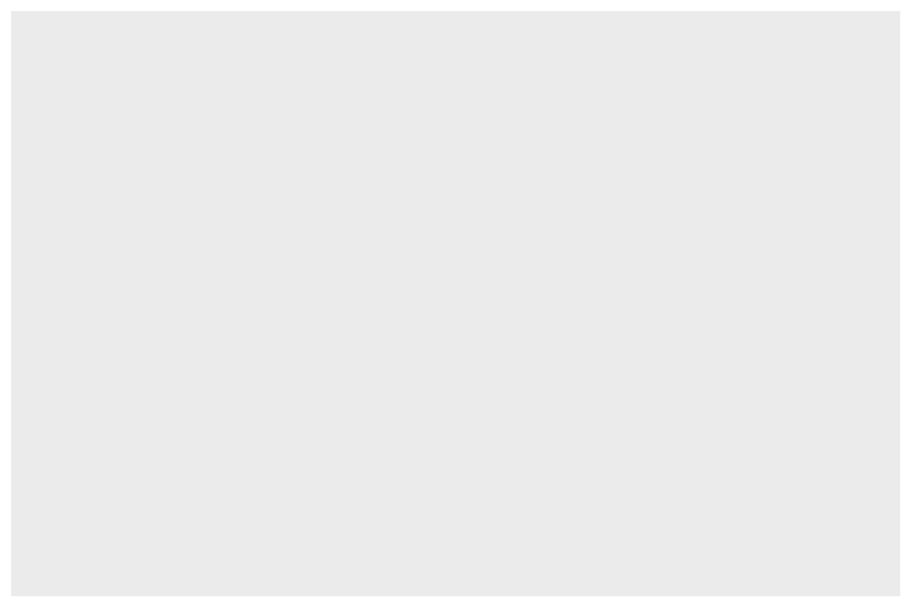

```r
ggplot(data = top10s)
```

## ggplot2 - Mapping aesthetics in geom functions (Basics)

We complete the graph by adding *layers* to `ggplot()`. This involves specifying a geom function, and mapping the variables in the dataset to visual properties.

The mapping argument (of any geom function) is always paired with `aes()`, and the `x` and `y` arguments of `aes()` specify the variables that are mapped to the x and y axes.

Generally, we have the following template:

```r
ggplot(data = top10s) +
  <GEOM_FUNCTION>(mapping = aes(<MAPPINGS>))
```

*Note that we will replace* **GEOM_FUNCTION** *with a particular function, and* **MAPPINGS** *with the desired mappings.*

Also note that the **+** operator is contained within the packages, and is specific to `ggplot` objects; used to add layers to plots.

## ggplot2 - Bar Graph: General

A simple chart which diagrammatically compares the **frequency distribution** of **discrete** categorical variables.

In our dataset **top10s**, we examine the distribution of **Genres** given by the `top.genre` variable, by using the function **geom_bar**.

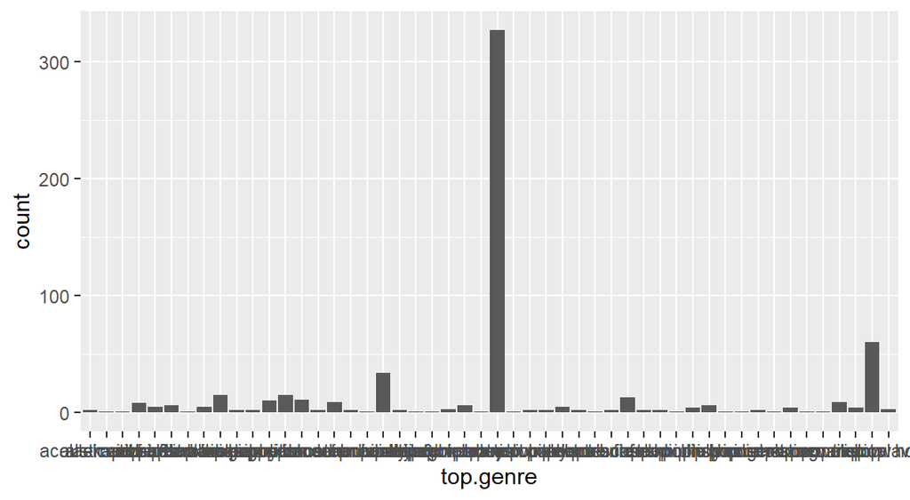

```r
ggplot(data = top10s) +
  geom_bar(mapping = aes(x = top.genre))
```

## ggplot2 - Bar Graph: Changing the aesthetics

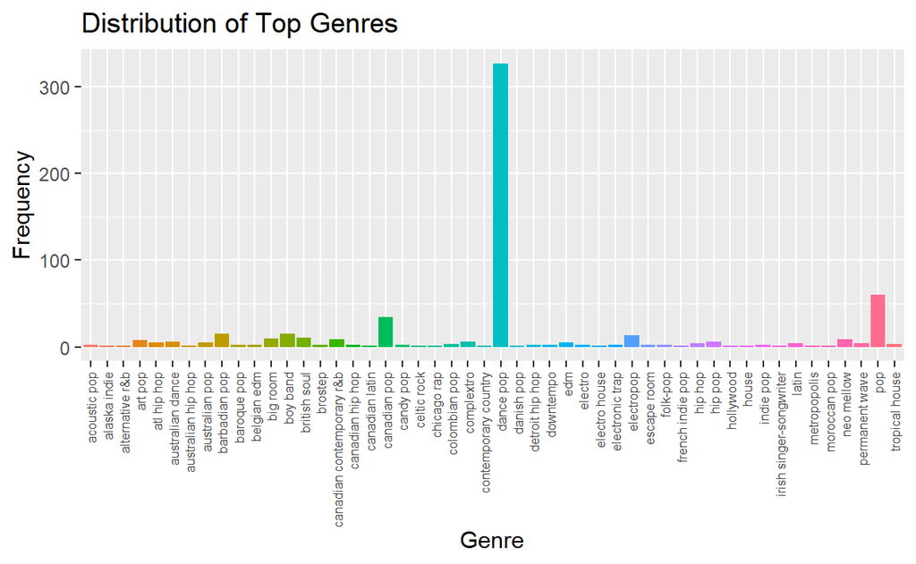

```r
ggplot(data = top10s) +
  geom_bar(mapping = aes(x = top.genre, fill = top.genre)) + # Colour - inside aes()
  labs(title = "Distribution of Top Genres") + # Add title
  xlab("Genre") + # x-axis label
  ylab("Frequency") + # y-axis label
  theme(axis.text.x = element_text(angle = 90, hjust = 1, vjust = 0.5, size = 6),
        legend.position = "none") # Labels and Adjustments
```

## ggplot2 - Histograms: General

Similar to bar graphs, but diagrammatically compares the **frequency distribution** of **continuous** variables. Histograms plot continuous data by grouping the ranges of the data into bins/intervals.

In our dataset **top10s**, we examine the distribution of **BPM** given by the `bpm` variable, by using the function **geom_histogram**.

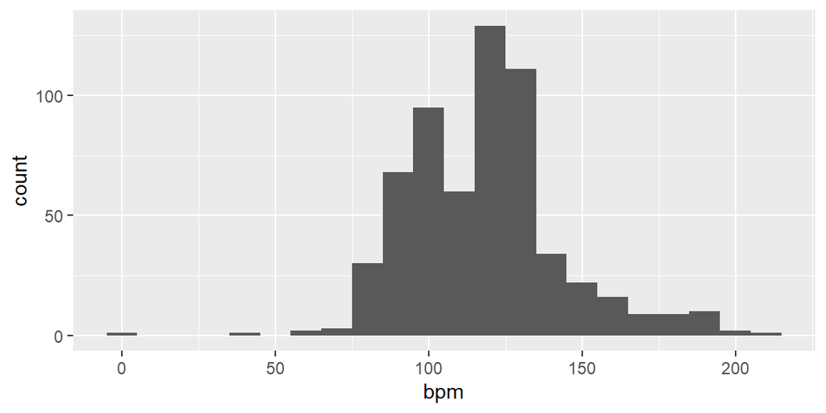

```r
ggplot(data = top10s) +
  geom_histogram(mapping = aes(x = bpm), binwidth = 10) # Bins of width 10
```

## ggplot2 - Histograms: Changing the Aesthetics

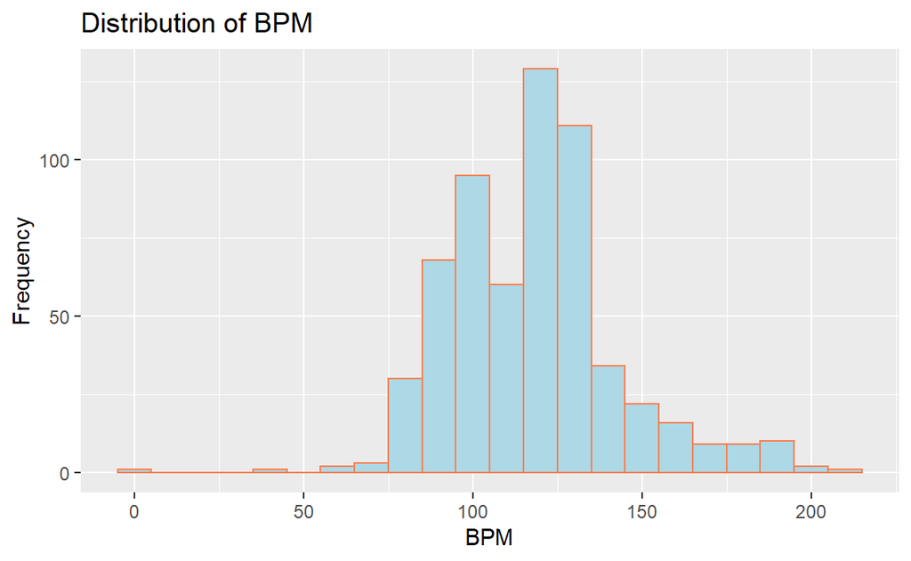

```r
ggplot(data = top10s) +
  geom_histogram(mapping = aes(x = bpm), binwidth = 10, fill = "lightblue",
                 colour = "coral") + # Coral linetype and Lightblue fill (outside aes())
  labs(title = "Distribution of BPM") + # Add title
  xlab("BPM") + # x-axis label
  ylab("Frequency") # y-axis label
```

## ggplot2 - Scatterplots: General

Used to visualise the **relationship** **two continuous** variables. Each data point is plotted with x and y coordinates corresponding to the numerical value of the two variables.

In our dataset **top10s**, we examine the relationship between **Speechiness** and **Popularity** given by `spch` and `pop` variables, by using the function **geom_point**.

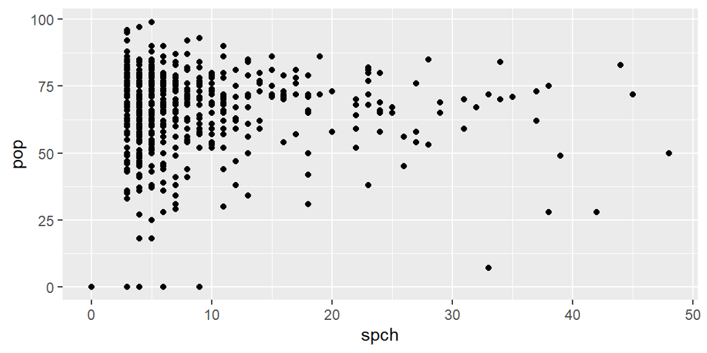

```r
ggplot(data = top10s) +
  geom_point(mapping = aes(x = spch, y = pop)) # x - Speechiness, y - Popularity
```

## ggplot2 - Scatterplots: Changing the Aesthetics

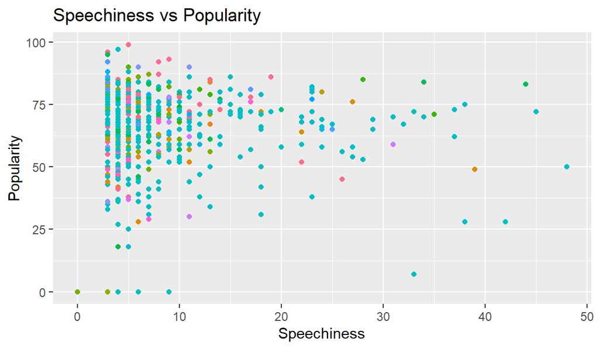

```r
ggplot(data = top10s) +
  geom_point(mapping = aes(x = spch, y = pop, colour = top.genre)) + # Colours based on genre
  labs(title = "Speechiness vs Popularity") + # Add title
  xlab("Speechiness") + # x-axis label
  ylab("Popularity") + # y-axis label
  theme(legend.position = "none") # Remove legend
```

## ggplot2 - Boxplots: General

Representing **groups of numerical data** through quartiles. Lower and upper quartiles shown as lines extending from a rectangle with most of the distribution (and the median) within the rectangle.

In our dataset **top10s**, we compare **Popularity** for **each** **Genre**. Provided by the `top.genre` and `pop` variables and using the function **geom_boxplot**.

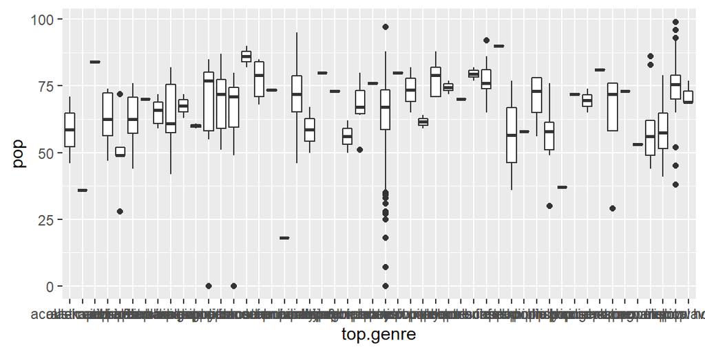

```r
ggplot(data = top10s) +
  geom_boxplot(mapping = aes(x = top.genre, y = pop))
```

## ggplot2 - Boxplots: Changing the Aesthetics

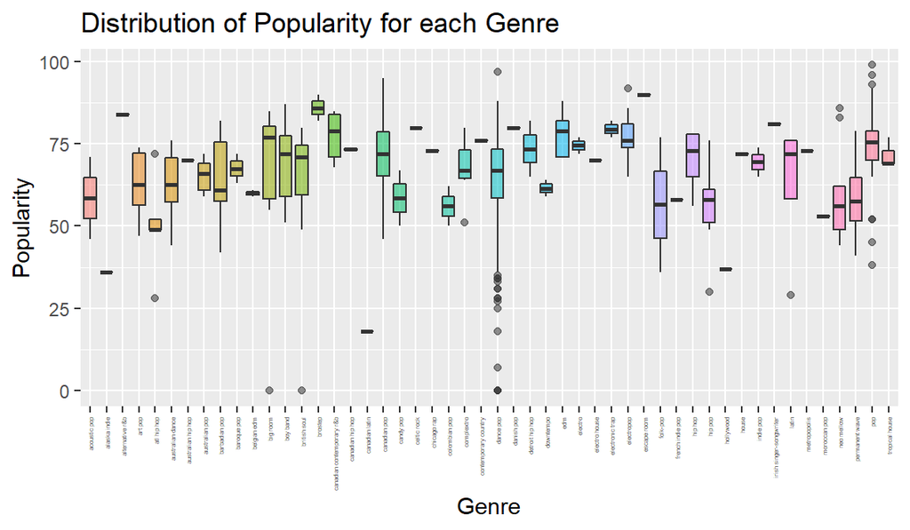

```r
ggplot(data = top10s) +
  geom_boxplot(mapping = aes(x = top.genre, y = pop,
                             fill = top.genre, alpha = 0.5)) + # Colour and transparency
  labs(title = "Distribution of Popularity for each Genre") + # Add title
  xlab("Genre") + # x-axis label
  ylab("Popularity") + # y-axis label
  theme(axis.text.x = element_text(angle = 90, hjust = 1, vjust = 0.5, size = 3),
        legend.position = "none") # Labels and Adjustments
```

## ggplot2 - Pie Chart: General

Circle which is divided into sectors that each represent a **proportion** of the whole.

[figure not shown]

```r
# Get proportions using dplyr package and create new dataframe
pie.df <- top10s %>%
  group_by(year) %>%
  summarise(n=n()) %>%
  mutate(n/sum(n)*100.0) %>%
  arrange(desc(n))

# Plot pie chart using new data frame using height of bars to represent values
ggplot(data = pie.df) +
  geom_bar(mapping = aes(x = "", y = as.factor(year)), stat = "identity", width = 1) +
  coord_polar("y", start = 0) # Making it circular
```

## ggplot2 - Pie Chart: Changing the Aesthetics

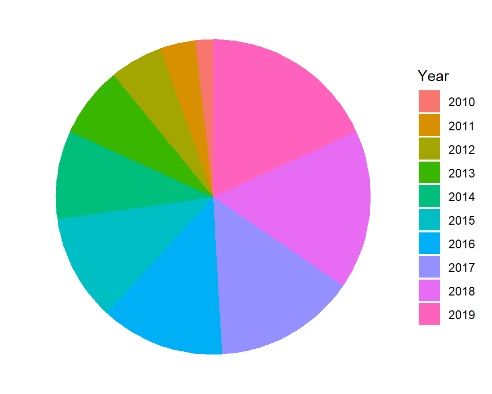

```r
ggplot(data = pie.df) +
  geom_bar(mapping = aes(x = "", y = as.factor(year), fill = as.factor(year)), # Colour
           stat = "identity", width = 1) +
  coord_polar("y", start = 0) +
  theme_void() + # Remove background, grid and numeric labels
  scale_fill_discrete(name = "Year") # Change legend title
```

## ggplot2 - Line Graphs (Time Series): General

Line graphs depict the relationship between two variables, connecting individual data points that display **quantitative** y-values over another quantitative or qualitative x-value (usually time). **Time Series** graphs are essentially line charts, except that the horizontal axis is exclusively time-based.

In our dataset **top10s**, we examine how **average** **BPM** changes over time (in **Years**) given by `bpm` and `year` variables, by using the function **geom_line**.

*First, we’ll need to average the BPMs for each Year (2010-2019) before plotting.*

```r
# Creating new dataframe
line.df <- top10s %>%
  group_by(year) %>% # Group by Year
  summarise(avg_bpm = mean(bpm)) # Average BPM for each Year

line.df
```

```
## # A tibble: 10 x 2
##     year avg_bpm
##
##  1  2010    122.
##  2  2011    119.
##  3  2012    121.
##  4  2013    122.
##  5  2014    123
##  6  2015    120.
##  7  2016    114.
##  8  2017    117.
##  9  2018    115.
## 10  2019    112.
```

## ggplot2 - Line Graphs (Time Series): Plotting

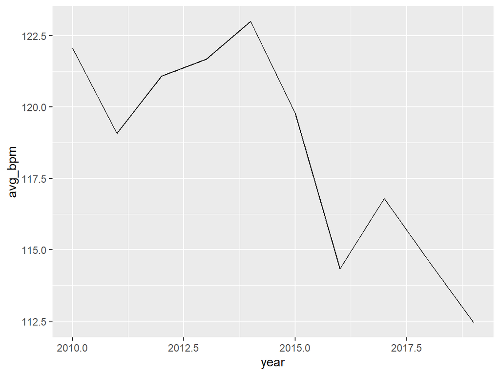

```r
ggplot(data = line.df) +
  geom_line(mapping = aes(x = year, y = avg_bpm))
```

## ggplot2 - Line Graphs (Time Series): Aesthetics

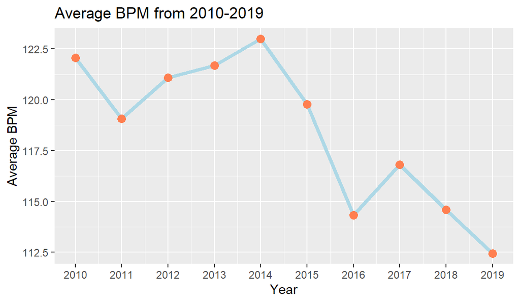

```r
ggplot(data = line.df) +
  geom_line(mapping = aes(x = year, y = avg_bpm), colour = "lightblue", lwd = 1.5) +
  geom_point(aes(x = year, y = avg_bpm), colour = "coral", size = 3) +  # Overlay geom_point
  scale_x_continuous(breaks = 2010:2019) + # Changing ticks
  labs(title = "Average BPM from 2010-2019") + # Add title
  xlab("Year") + # x-axis label
  ylab("Average BPM") # y-axis label
```

## Base R - Heatmaps: General

Heatmaps represent the magnitude of **numerical** values by **colours**, providing an immediate visual summary of the data. Heatmaps are versatile; able to adapt to various forms of analytics.

In our dataset **top10s**, we will construct a **correlation** heatmap between **all 10 numeric variables** (excluding Year), by using the **heatmap()** function in **Base R**.

*First, we need to output a correlation matrix for our 10 variables.*

```r
corrmat <- round(cor(top10s[,6:15]), 2) # Correlation Matrix of last 10 Variables, rounded

corrmat # Display Correlation Matrix
```

```
##         bpm  nrgy  dnce    dB  live   val   dur acous  spch   pop
## bpm    1.00  0.13 -0.13  0.18  0.08  0.02 -0.03 -0.11  0.06  0.02
## nrgy   0.13  1.00  0.17  0.54  0.19  0.41 -0.14 -0.56  0.11 -0.06
## dnce  -0.13  0.17  1.00  0.23 -0.03  0.50 -0.18 -0.24 -0.03  0.12
## dB     0.18  0.54  0.23  1.00  0.08  0.28 -0.10 -0.19  0.00  0.16
## live   0.08  0.19 -0.03  0.08  1.00  0.02  0.10 -0.10  0.14 -0.08
## val    0.02  0.41  0.50  0.28  0.02  1.00 -0.26 -0.25  0.12  0.04
## dur   -0.03 -0.14 -0.18 -0.10  0.10 -0.26  1.00  0.09  0.05 -0.10
## acous -0.11 -0.56 -0.24 -0.19 -0.10 -0.25  0.09  1.00  0.00  0.03
## spch   0.06  0.11 -0.03  0.00  0.14  0.12  0.05  0.00  1.00 -0.04
## pop    0.02 -0.06  0.12  0.16 -0.08  0.04 -0.10  0.03 -0.04  1.00
```

## Base R - Heatmaps: Plotting

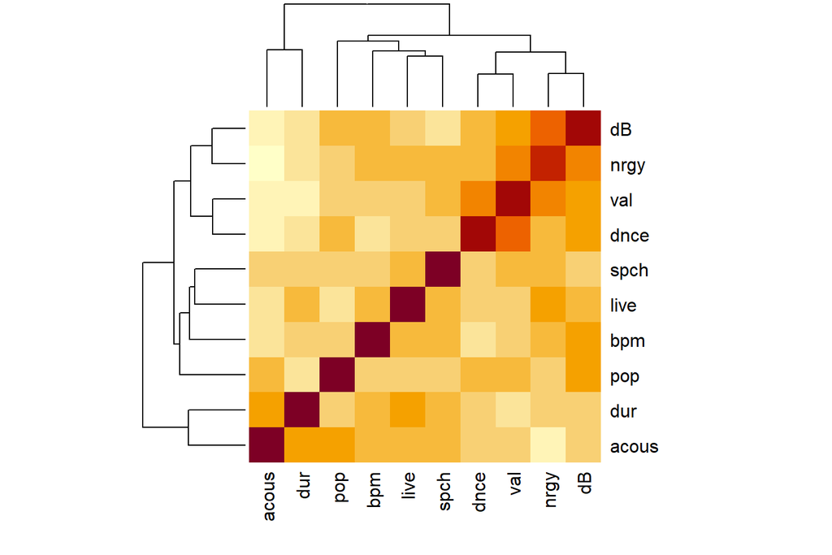

```r
heatmap(corrmat)
```

## Base R - Heatmaps: Aesthetics

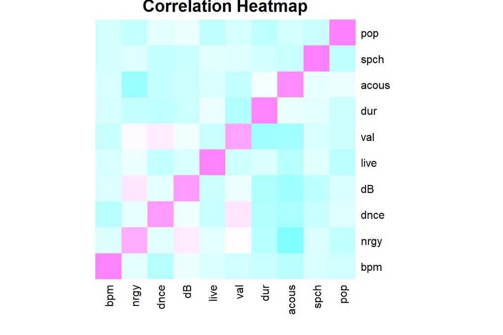

```r
# Base R's colour palettes: terrain.color(), rainbow(), heat.colors(), topo.colors()
heatmap(corrmat, Colv = NA, Rowv = NA, col = cm.colors(256), main = "Correlation Heatmap")
```

## ggplot2 - Bonus: Overlaying Graphs 1

- Overlaying a **Scatter Plot** and a **Smooth Curve OBF**.

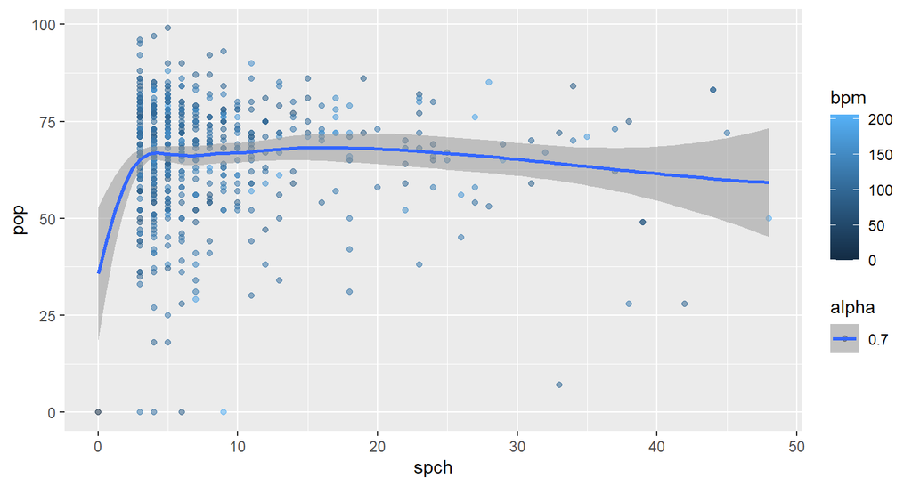

```r
ggplot(top10s, aes(x = spch, y = pop, colour = bpm, alpha = 0.7)) +
  geom_point() +
  geom_smooth()
```

## ggplot2 - Bonus: Overlaying Graphs 2

- Overlaying **two Histograms**.

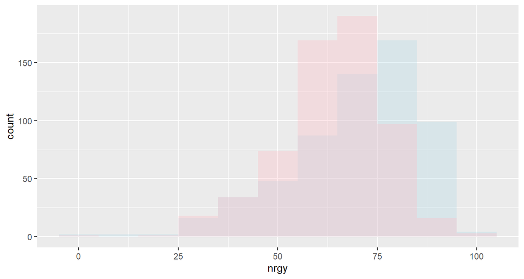

```r
ggplot(top10s) +
  geom_histogram(aes(x = nrgy), binwidth = 10, fill = "lightblue", alpha = 0.3) +
  geom_histogram(aes(x = dnce), binwidth = 10, fill = "lightpink", alpha = 0.3)
```

## ggplot2 - Bonus: Allocating sizes

- Sizes of circles in **Scatterplot** are indicative of the **magnitude** of another variable.

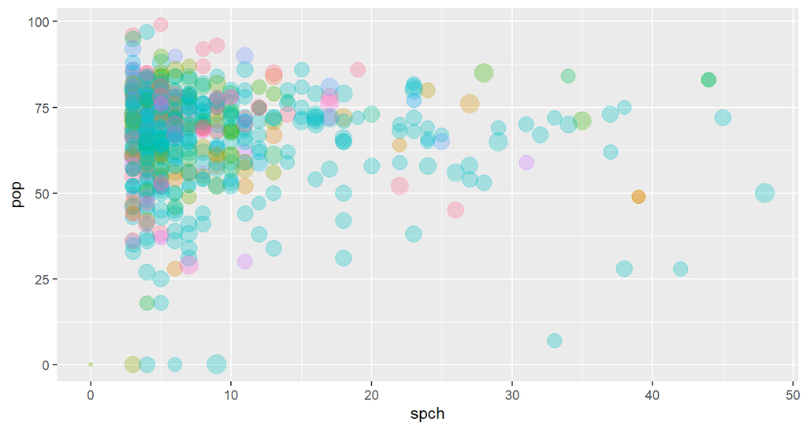

```r
ggplot(top10s) +
  geom_point(aes(x = spch, y = pop, colour = top.genre, size = bpm), alpha = 0.3) + # Scale circle size depending on BPM
    theme(legend.position = "none") # Remove legend
```

## ggplot2 - Bonus: Stacked bar graphs

- Mapping the **fill** aesthetic to another variable `artist`: Bars become stacked and each rectangle (representing a certain `genre`) comprises of the `artists` that make up the `genre`.

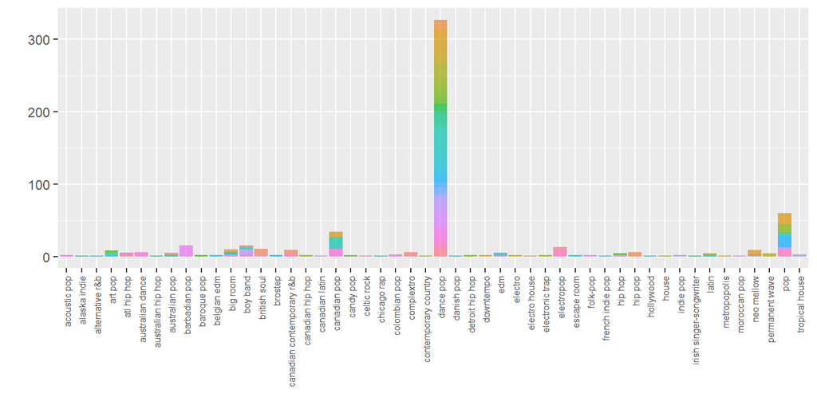

```r
ggplot(data = top10s) +
  geom_bar(mapping = aes(x = top.genre, fill = artist), alpha = 0.7) + # Fill according to artist
  xlab("") + ylab("") +
  theme(axis.text.x = element_text(angle = 90, hjust = 1, vjust = 0.5, size = 6), legend.position = "none")
```

## Extension - Defining functions for efficiency

Functions can be used to prevent repetition when setting the parameters, especially when multiple, similar plots are required.

```r
create_scatter <- function(df, xvar, yvar, xname, yname, title){
  ggplot(df) +
    geom_point(aes(x = {{xvar}}, y = {{yvar}}, colour = pop)) + # Colour based on Popularity
    labs(title = title) + # Title
    scale_x_discrete(name = xname) + # x-axis label
    scale_y_continuous(name = yname) + # y-axis label
    theme(legend.position = "none") # Remove legend
}
```

**Example**

```r
# Create a scatterplot (using user-defined function) of BPM and Liveliness
create_scatter(top10s, bpm, live, "Beats Per Minute", "Liveliness", "BPM vs Liveliness")
```

[output not shown]

Note: *Use `{{` and `}}` when defining which variable to call when creating your function, otherwise it will return* `object 'variable' not found`.

## Extension - Automating Plotting Process

We can use **loops** function to create plots *quickly and easily*. First, we create an empty list:

```r
plot_list = list() # Empty list
```

Then, we create a **for** loop to store the *ith variable plot* (with `popularity` variable) in the list, iterated:

```r
for(i in 6:15){
  plot <- ggplot(top10s) + # For each iteration, store the plot made with the ith variable and popularity
    geom_point(aes(x = top10s[,i], y = pop, colour = top.genre)) + # Scatterplot
    theme(legend.position = "none") + # Remove legend
    xlab(colnames(top10s)[i]) + # x-axis label
    ylab("Popularity") # y-axis label
  plot_list[[i]] = plot # Add the ith plot to the plot_list
}
```

Finally, we **export** our graphs using R’s native functions:

```r
pdf("myplots.pdf") # Create empty pdf file named "myplots"
for(i in 6:15){ # Print each plot in plot_list variable (on separate page in pdf)
  print(plot_list[[i]])
}
dev.off() # Complete action and save PDF file
```

## ggplot2 - Exporting your graphs: `ggsave()`

`ggsave()` is a convenient function in the **ggplot2** package which defaults to saving the **last plot displayed**.

```r
ggsave("myfilename.png", width = 28, height = 9, dpi = 300)
# Specifying Name, Type, Width, Height and Resolution
```

- There are other arguments it can take as well:
  - `plot`: Specify which plot (otherwise it will default to last plot)
  - `device`: Device to use: e.g. “pdf”, “jpeg”, “png” etc.
  - `units`: (“in”,“cm” or “mm”)
  - `limitsize`: TRUE (default) will not save images larger than 50x50 inches

See more: https://ggplot2.tidyverse.org/reference/ggsave.html

## R - Exporting your graphs using Base R

1. After creating your graph, you can simply go to the **Plots Panel -> Export -> Save as Image or Save as PDF** and specify your dimensions and format.
2. Using code:
- First, specify the file format.
- Enter your plotting commands (or call the saved plot)
- Then use `dev.off()` command.

```r
jpeg("my_plot_name.jpg") # Specify format and name
plot(x,y) OR myplot # Plot the graph or call the graph
dev.off() # To complete process (important)
```

Common Formats:

- `pdf("rplot.pdf")`: PDF file
- `png("rplot.png")`: PNG file
- `jpeg("rplot.jpg")`: JPEG file
- `bmp("rplot.bmp")`: BMP file

## Useful links for Data Visualisation in R

- ggplot2 Cheatsheet
  - https://rstudio.com/wp-content/uploads/2015/03/ggplot2-cheatsheet.pdf
- Base R - Data Visualisation Cheatsheet
  - https://www.analyticsvidhya.com/wp-content/uploads/2015/08/Comprehensive-Guide-to-Data-Visualization-in-R-FINAL-1.jpg
- Periodic Table of Visualisation Methods
  - https://www.visual-literacy.org/periodic_table/periodic_table.html#
- More Visualisation Methods in R
  - http://r-statistics.co/Top50-Ggplot2-Visualizations-MasterList-R-Code.html